# Overview of the mvgam package

Nicholas J Clark

2025-03-14

The purpose of this vignette is to give a general overview of the `mvgam` package and its primary functions.

## Dynamic GAMs

`mvgam` is designed to propagate unobserved temporal processes to capture latent dynamics in the observed time series. This works in a state-space format, with the temporal *trend* evolving independently of the observation process. An introduction to the package and some worked examples are also shown in this seminar: [Ecological Forecasting with Dynamic Generalized Additive Models](https://www.youtube.com/watch?v=0zZopLlomsQ). Briefly, assume $\tilde{\boldsymbol{y}}_{i,t}$ is the conditional expectation of response variable $\boldsymbol{i}$ at time $\boldsymbol{t}$. Assuming $\boldsymbol{y_i}$ is drawn from an exponential distribution with an invertible link function, the linear predictor for a multivariate Dynamic GAM can be written as:

$$for~i~in~1:N_{series}~...$$
$$for~t~in~1:N_{timepoints}~...$$

$$g^{-1}(\tilde{\boldsymbol{y}}_{i,t})=\alpha_{i}+\sum\limits_{j=1}^J\boldsymbol{s}_{i,j,t}\boldsymbol{x}_{j,t}+\boldsymbol{Z}\boldsymbol{z}_{k,t}\,,$$
Here $\alpha$ are the unknown intercepts, the $\boldsymbol{s}$’s are unknown smooth functions of covariates ($\boldsymbol{x}$’s), which can potentially vary among the response series, and $\boldsymbol{z}$ are dynamic latent processes. Each smooth function $\boldsymbol{s_j}$ is composed of basis expansions whose coefficients, which must be estimated, control the functional relationship between $\boldsymbol{x}_{j}$ and $g^{-1}(\tilde{\boldsymbol{y}})$. The size of the basis expansion limits the smooth’s potential complexity. A larger set of basis functions allows greater flexibility. For more information on GAMs and how they can smooth through data, see [this blogpost on how to interpret nonlinear effects from Generalized Additive Models](https://ecogambler.netlify.app/blog/interpreting-gams/). Latent processes are captured with $\boldsymbol{Z}\boldsymbol{z}_{i,t}$, where $\boldsymbol{Z}$ is an $i~by~k$ matrix of loading coefficients (which can be fixed or a combination of fixed and freely estimated parameters) and $\boldsymbol{z}_{k,t}$ are a set of $K$ latent factors that can also include their own GAM linear predictors (see the [State-Space models vignette](https://nicholasjclark.github.io/mvgam/articles/trend_formulas.html)), the [N-mixtures vignette](https://nicholasjclark.github.io/mvgam/articles/nmixtures.html) and the example in [`jsdgam`](https://nicholasjclark.github.io/mvgam/reference/jsdgam.html) to get an idea of how flexible these processes can be.

Several advantages of GAMs are that they can model a diversity of response families, including discrete distributions (i.e. Poisson, Negative Binomial, Gamma) that accommodate common ecological features such as zero-inflation or overdispersion, and that they can be formulated to include hierarchical smoothing for multivariate responses. `mvgam` supports a number of different observation families, which are summarized below:

## Supported observation families

| Distribution | Function | Support | Extra parameter(s) |
| --- | --- | --- | --- |
| Gaussian (identity link) | `gaussian()` | Real values in $(-\infty, \infty)$ | $\sigma$ |
| Student’s T (identity link) | `student-t()` | Heavy-tailed real values in $(-\infty, \infty)$ | $\sigma$, $\nu$ |
| LogNormal (identity link) | `lognormal()` | Positive real values in $[0, \infty)$ | $\sigma$ |
| Gamma (log link) | `Gamma()` | Positive real values in $[0, \infty)$ | $\alpha$ |
| Beta (logit link) | `betar()` | Real values (proportional) in $[0,1]$ | $\phi$ |
| Bernoulli (logit link) | `bernoulli()` | Binary data in ${0,1}$ | - |
| Poisson (log link) | `poisson()` | Non-negative integers in $(0,1,2,...)$ | - |
| Negative Binomial2 (log link) | `nb()` | Non-negative integers in $(0,1,2,...)$ | $\phi$ |
| Binomial (logit link) | `binomial()` | Non-negative integers in $(0,1,2,...)$ | - |
| Beta-Binomial (logit link) | `beta_binomial()` | Non-negative integers in $(0,1,2,...)$ | $\phi$ |
| Poisson Binomial N-mixture (log link) | `nmix()` | Non-negative integers in $(0,1,2,...)$ | - |

For all supported observation families, any extra parameters that need to be estimated (i.e. the $\sigma$ in a Gaussian model or the $\phi$ in a Negative Binomial model) are by default estimated independently for each series. However, users can opt to force all series to share extra observation parameters using `share_obs_params = TRUE` in `mvgam()`. Note that default link functions cannot currently be changed.

## Supported temporal dynamic processes

As stated above, the latent processes can take a wide variety of forms, some of which can be multivariate to allow the different observational variables to interact or be correlated. When using the `mvgam()` function, the user chooses between different process models with the `trend_model` argument. Available process models are described in detail below.

### Correlated multivariate processes

If more than one observational unit (usually referred to as ‘series’) is included in `data` $(N_{series} > 1)$, use `trend_model = ZMVN()` to set up a model where the outcomes for different observational units may be correlated according to:

$$\begin{align*}
z_{t} & \sim \text{MVNormal}(0, \Sigma) \end{align*}$$

The covariance matrix $\Sigma$ will capture potentially correlated process errors. It is parameterised using a Cholesky factorization, which requires priors on the series-level variances $\sigma$ and on the strength of correlations using `Stan`’s `lkj_corr_cholesky` distribution. Note that this `trend_model` does not assume that measurements occur over *time*, as users can specify what variable in the `data` represents the unit of analysis (i.e. outcomes could be counts of different *species* across different *sites* or *regions*, for example; see [`?ZMVN()](https://nicholasjclark.github.io/mvgam/reference/ZMVN.html) for guidelines).

### Independent Random Walks

Use `trend_model = 'RW'` or `trend_model = RW()` to set up a model where each series in `data` has independent latent temporal dynamics of the form:

$$\begin{align*}
z_{i,t} & \sim \text{Normal}(z_{i,t-1}, \sigma_i)
\end{align*}$$

Process error parameters $\sigma$ are modeled independently for each series. If a moving average process is required, use `trend_model = RW(ma = TRUE)` to set up the following:

$$\begin{align*}
z_{i,t} & = z_{i,t-1} + \theta_i * error_{i,t-1} + error_{i,t} \\
error_{i,t} & \sim \text{Normal}(0, \sigma_i)
\end{align*}$$

Moving average coefficients $\theta$ are independently estimated for each series and will be forced to be stationary by default $(abs(\theta)<1)$. Only moving averages of order $q=1$ are currently allowed.

### Multivariate Random Walks

If more than one series is included in `data` $(N_{series} > 1)$, a multivariate Random Walk can be set up using `trend_model = RW(cor = TRUE)`, resulting in the following:

$$\begin{align*}
z_{t} & \sim \text{MVNormal}(z_{t-1}, \Sigma)
\end{align*}$$

Where the latent process estimate $z_t$ now takes the form of a vector. The covariance matrix $\Sigma$ will capture contemporaneously correlated process errors. It is parameterised using a Cholesky factorization, which requires priors on the series-level variances $\sigma$ and on the strength of correlations using `Stan`’s `lkj_corr_cholesky` distribution.

Moving average terms can also be included for multivariate random walks, in which case the moving average coefficients $\theta$ will be parameterised as an $N_{series} * N_{series}$ matrix

### Autoregressive processes

Autoregressive models up to $p=3$, in which the autoregressive coefficients are estimated independently for each series, can be used by specifying `trend_model = 'AR1'`, `trend_model = 'AR2'`, `trend_model = 'AR3'`, or `trend_model = AR(p = 1, 2, or 3)`. For example, a univariate AR(1) model takes the form:

$$\begin{align*}
z_{i,t} & \sim \text{Normal}(ar1_i * z_{i,t-1}, \sigma_i)
\end{align*}$$

All options are the same as for Random Walks, but additional options will be available for placing priors on the autoregressive coefficients. By default, these coefficients will not be forced into stationarity, but users can impose this restriction by changing the upper and lower bounds on their priors. See `?get_mvgam_priors` for more details.

### Vector Autoregressive processes

A Vector Autoregression of order $p=1$ can be specified if $N_{series} > 1$ using `trend_model = 'VAR1'` or `trend_model = VAR()`. A VAR(1) model takes the form:

$$\begin{align*}
z_{t} & \sim \text{Normal}(A * z_{t-1}, \Sigma)
\end{align*}$$

Where $A$ is an $N_{series} * N_{series}$ matrix of autoregressive coefficients in which the diagonals capture lagged self-dependence (i.e. the effect of a process at time $t$ on its own estimate at time $t+1$), while off-diagonals capture lagged cross-dependence (i.e. the effect of a process at time $t$ on the process for another series at time $t+1$). By default, the covariance matrix $\Sigma$ will assume no process error covariance by fixing the off-diagonals to $0$. To allow for correlated errors, use `trend_model = 'VAR1cor'` or `trend_model = VAR(cor = TRUE)`. A moving average of order $q=1$ can also be included using `trend_model = VAR(ma = TRUE, cor = TRUE)`.

Note that for all VAR models, stationarity of the process is enforced with a structured prior distribution that is described in detail in [Heaps 2022](https://www.tandfonline.com/doi/full/10.1080/10618600.2022.2079648)

Heaps, Sarah E. “[Enforcing stationarity through the prior in vector autoregressions.](https://www.tandfonline.com/doi/full/10.1080/10618600.2022.2079648)” *Journal of Computational and Graphical Statistics* 32.1 (2023): 74-83.

### Hierarchical processes

Several of the above-mentioned `trend_model` options can be modified to account for grouping structures in `data` by setting up hierarchical latent processes. If an optional grouping variable (`gr`; which must be a `factor` in the supplied `data`) exists, users can model hierarchical residual correlation structures. where the residual correlations for a specific level of `gr` are modelled hierarchically:

$$\begin{align*}
\Omega_{group} & = \alpha_{cor}\Omega_{global} + (1 -
\alpha_{cor})\Omega_{group, local} \end{align*}$$

where $\Omega_{global}$ is a *global* correlation matrix, $\Omega_{group, local}$ is a *local deviation* correlation matrix and $\alpha_{cor}$ is a weighting parameter controlling how strongly the local correlation matrix $\Omega_{group}$ (i.e. the derived correlation matrix that will be used for each level of the grouping factor `gr`) is shrunk towards the global correlation matrix $\Omega_{global}$ (larger values of $\alpha_{cor}$ indicate a greater degree of shrinkage, i.e. a greater degree of partial pooling). This option is valuable for many types of designs where the same observational units (i.e. *financial assets* or *species*, for example) are measured in different strata (i.e. *regions*, *countries* or *experimental units*, for example). Currently hierarchical correlations can be included for `AR()`, `VAR()` or `ZMVN()` `trend_model` options.

### Gaussian Processes

The final option for modelling temporal dynamics is to use a Gaussian Process with squared exponential kernel. These are set up independently for each series (there is currently no multivariate GP option), using `trend_model = 'GP'`. The dynamics for each latent process are modelled as:

$$\begin{align*}
z & \sim \text{MVNormal}(0, \Sigma_{error}) \\
\Sigma_{error}[t_i, t_j] & = \alpha^2 * exp(-0.5 * ((|t_i - t_j| /
\rho))^2) \end{align*}$$

The latent dynamic process evolves from a complex, high-dimensional Multivariate Normal distribution which depends on $\rho$ (often called the length scale parameter) to control how quickly the correlations between the model’s errors decay as a function of time. For these models, covariance decays exponentially fast with the squared distance (in time) between the observations. The functions also depend on a parameter $\alpha$, which controls the marginal variability of the temporal function at all points; in other words it controls how much the GP term contributes to the linear predictor. `mvgam` capitalizes on some advances that allow GPs to be approximated using Hilbert space basis functions, which [considerably speed up computation at little cost to accuracy or prediction performance](https://link.springer.com/article/10.1007/s11222-022-10167-2).

### Piecewise logistic and linear trends

Modeling growth for many types of time series is often similar to modeling population growth in natural ecosystems, where there series exhibits nonlinear growth that saturates at some particular carrying capacity. The logistic trend model available in {`mvgam`} allows for a time-varying capacity $C(t)$ as well as a non-constant growth rate. Changes in the base growth rate $k$ are incorporated by explicitly defining changepoints throughout the training period where the growth rate is allowed to vary. The changepoint vector $a$ is represented as a vector of `1`s and `0`s, and the rate of growth at time $t$ is represented as $k+a(t)^T\delta$. Potential changepoints are selected uniformly across the training period, and the number of changepoints, as well as the flexibility of the potential rate changes at these changepoints, can be controlled using `trend_model = PW()`. The full piecewise logistic growth model is then:

$$\begin{align*}
z_t & = \frac{C_t}{1 +
\exp(-(k+a(t)^T\delta)(t-(m+a(t)^T\gamma)))} \end{align*}$$

For time series that do not appear to exhibit saturating growth, a piece-wise constant rate of growth can often provide a useful trend model. The piecewise linear trend is defined as:

$$\begin{align*}
z_t & = (k+a(t)^T\delta)t +
(m+a(t)^T\gamma) \end{align*}$$

In both trend models, $m$ is an offset parameter that controls the trend intercept. Because of this parameter, it is not recommended that you include an intercept in your observation formula because this will not be identifiable. You can read about the full description of piecewise linear and logistic trends [in this paper by Taylor and Letham](https://www.tandfonline.com/doi/abs/10.1080/00031305.2017.1380080).

Sean J. Taylor and Benjamin Letham. “[Forecasting at scale.](https://www.tandfonline.com/doi/full/10.1080/00031305.2017.1380080)” *The American Statistician* 72.1 (2018): 37-45.

### Continuous time AR(1) processes

Most trend models in the `mvgam()` function expect time to be measured in regularly-spaced, discrete intervals (i.e. one measurement per week, or one per year for example). But some time series are taken at irregular intervals and we’d like to model autoregressive properties of these. The `trend_model = CAR()` can be useful to set up these models, which currently only support autoregressive processes of order `1`. The evolution of the latent dynamic process follows the form:

$$\begin{align*}
z_{i,t} & \sim \text{Normal}(ar1_i^{distance} * z_{i,t-1}, \sigma_i)
\end{align*}$$

Where $distance$ is a vector of non-negative measurements of the time differences between successive observations. See the **Examples** section in `?CAR` for an illustration of how to set these models up.

## Regression formulae

`mvgam` supports an observation model regression formula, built off the `mgcv` package, as well as an optional process model regression formula. The formulae supplied to are exactly like those supplied to `glm()` except that smooth terms, `s()`, `te()`, `ti()` and `t2()`, time-varying effects using `dynamic()`, monotonically increasing (using `s(x, bs = 'moi')`) or decreasing splines (using `s(x, bs = 'mod')`; see `?smooth.construct.moi.smooth.spec` for details), as well as Gaussian Process functions using `gp()`, can be added to the right hand side (and `.` is not supported in `mvgam` formulae). See `?mvgam_formulae` for more guidance.

For setting up State-Space models, the optional process model formula can be used (see [the State-Space model vignette](https://nicholasjclark.github.io/mvgam/articles/trend_formulas.html) and [the shared latent states vignette](https://nicholasjclark.github.io/mvgam/articles/trend_formulas.html) for guidance on using trend formulae).

## Example time series data

The ‘portal_data’ object contains time series of rodent captures from the Portal Project, [a long-term monitoring study based near the town of Portal, Arizona](https://portal.weecology.org/). Researchers have been operating a standardized set of baited traps within 24 experimental plots at this site since the 1970’s. Sampling follows the lunar monthly cycle, with observations occurring on average about 28 days apart. However, missing observations do occur due to difficulties accessing the site (weather events, COVID disruptions etc…). You can read about the full sampling protocol [in this preprint by Ernest et al on the Biorxiv](https://www.biorxiv.org/content/10.1101/332783v3.full).

```r
data("portal_data")
```

As the data come pre-loaded with the `mvgam` package, you can read a little about it in the help page using `?portal_data`. Before working with data, it is important to inspect how the data are structured, first using `head`:

```r
head(portal_data)
```

```
#>   time series captures  ndvi_ma12    mintemp
#> 1    1     DM       20 -0.1721441 -0.7963381
#> 2    1     DO        2 -0.1721441 -0.7963381
#> 3    1     PB        0 -0.1721441 -0.7963381
#> 4    1     PP        0 -0.1721441 -0.7963381
#> 5    2     DM       NA -0.2373635 -1.3347160
#> 6    2     DO       NA -0.2373635 -1.3347160
```

But the `glimpse` function in `dplyr` is also useful for understanding how variables are structured

```r
dplyr::glimpse(portal_data)
```

```
#> Rows: 320
#> Columns: 5
#> $ time      <int> 1, 1, 1, 1, 2, 2, 2, 2, 3, 3, 3, 3, 4, 4, 4, 4, 5, 5, 5, 5, …
#> $ series    <fct> DM, DO, PB, PP, DM, DO, PB, PP, DM, DO, PB, PP, DM, DO, PB, …
#> $ captures  <int> 20, 2, 0, 0, NA, NA, NA, NA, 36, 5, 0, 0, 40, 3, 0, 1, 29, 3…
#> $ ndvi_ma12 <dbl> -0.172144125, -0.172144125, -0.172144125, -0.172144125, -0.2…
#> $ mintemp   <dbl> -0.79633807, -0.79633807, -0.79633807, -0.79633807, -1.33471…
```

We will focus analyses on the time series of captures for one specific rodent species, the Desert Pocket Mouse *Chaetodipus penicillatus*. This species is interesting in that it goes into a kind of “hibernation” during the colder months, leading to very low captures during the winter period

## Manipulating data for modelling

Manipulating the data into a ‘long’ format is necessary for modelling in `mvgam`. By ‘long’ format, we mean that each `series x time` observation needs to have its own entry in the `dataframe` or `list` object that we wish to use as data for modelling. A simple example can be viewed by simulating data using the `sim_mvgam` function. See `?sim_mvgam` for more details

```r
data <- sim_mvgam(n_series = 4, T = 24)
head(data$data_train, 12)
```

```
#>    y season year   series time
#> 1  0      1    1 series_1    1
#> 2  2      1    1 series_2    1
#> 3  0      1    1 series_3    1
#> 4  0      1    1 series_4    1
#> 5  1      2    1 series_1    2
#> 6  6      2    1 series_2    2
#> 7  2      2    1 series_3    2
#> 8  1      2    1 series_4    2
#> 9  1      3    1 series_1    3
#> 10 1      3    1 series_2    3
#> 11 2      3    1 series_3    3
#> 12 5      3    1 series_4    3
```

Notice how we have four different time series in these simulated data, but we do not spread the outcome values into different columns. Rather, there is only a single column for the outcome variable, labelled `y` in these simulated data. We also must supply a variable labelled `time` to ensure the modelling software knows how to arrange the time series when building models. This setup still allows us to formulate multivariate time series models, as you can see in the [State-Space vignette](https://nicholasjclark.github.io/mvgam/articles/trend_formulas.html). Below are the steps needed to shape our `portal_data` object into the correct form. First, we create a `time` variable, select the column representing counts of our target species (`PP`), and select appropriate variables that we can use as predictors

```r
portal_data %>%
  # Filter the data to only contain captures of the 'PP'
  dplyr::filter(series == 'PP') %>%
  droplevels() %>%
  dplyr::mutate(count = captures) %>%
  # Add a 'year' variable
  dplyr::mutate(year = sort(rep(1:8, 12))[time]) %>%
  # Select the variables of interest to keep in the model_data
  dplyr::select(series, year, time, count, mintemp, ndvi_ma12) -> model_data
```

The data now contain six variables:  
`series`, a factor indexing which time series each observation belongs to  
`year`, the year of sampling  
`time`, the indicator of which time step each observation belongs to  
`count`, the response variable representing the number of captures of the species `PP` in each sampling observation  
`mintemp`, the monthly average minimum temperature at each time step  
`ndvi_ma12`, a 12-month moving average of the monthly Normalized Difference Vegetation Index at each time step

Now check the data structure again

```r
head(model_data)
```

```
#>   series year time count     mintemp   ndvi_ma12
#> 1     PP    1    1     0 -0.79633807 -0.17214413
#> 2     PP    1    2    NA -1.33471597 -0.23736348
#> 3     PP    1    3     0 -1.24166462 -0.21212064
#> 4     PP    1    4     1 -1.08048145 -0.16043812
#> 5     PP    1    5     7 -0.42447625 -0.08267729
#> 6     PP    1    6     7  0.06532892 -0.03692877
```

```r
dplyr::glimpse(model_data)
```

```
#> Rows: 80
#> Columns: 6
#> $ series    <fct> PP, PP, PP, PP, PP, PP, PP, PP, PP, PP, PP, PP, PP, PP, PP, …
#> $ year      <int> 1, 1, 1, 1, 1, 1, 1, 1, 1, 1, 1, 1, 2, 2, 2, 2, 2, 2, 2, 2, …
#> $ time      <int> 1, 2, 3, 4, 5, 6, 7, 8, 9, 10, 11, 12, 13, 14, 15, 16, 17, 1…
#> $ count     <int> 0, NA, 0, 1, 7, 7, 8, 8, 4, NA, 0, 0, 0, 0, 0, 0, NA, 2, 4, …
#> $ mintemp   <dbl> -0.79633807, -1.33471597, -1.24166462, -1.08048145, -0.42447…
#> $ ndvi_ma12 <dbl> -0.172144125, -0.237363477, -0.212120638, -0.160438125, -0.0…
```

You can also summarize multiple variables, which is helpful to search for data ranges and identify missing values

```r
summary(model_data)
```

```
#>  series       year           time           count           mintemp
#>  PP:80   Min.   :1.00   Min.   : 1.00   Min.   : 0.000   Min.   :-2.0978
#>          1st Qu.:2.00   1st Qu.:20.75   1st Qu.: 1.000   1st Qu.:-1.0808
#>          Median :4.00   Median :40.50   Median : 5.000   Median :-0.4091
#>          Mean   :3.85   Mean   :40.50   Mean   : 5.222   Mean   :-0.2151
#>          3rd Qu.:5.25   3rd Qu.:60.25   3rd Qu.: 8.000   3rd Qu.: 0.6133
#>          Max.   :7.00   Max.   :80.00   Max.   :21.000   Max.   : 1.4530
#>                                         NA's   :17
#>    ndvi_ma12
#>  Min.   :-0.66884
#>  1st Qu.:-0.20869
#>  Median :-0.16517
#>  Mean   :-0.09501
#>  3rd Qu.:-0.03440
#>  Max.   : 0.74831
#>
```

We have some `NA`s in our response variable `count`. These observations will generally be thrown out by most modelling packages in . But as you will see when we work through the tutorials, `mvgam` keeps these in the data so that predictions can be automatically returned for the full dataset. The time series and some of its descriptive features can be plotted using `plot_mvgam_series()`:

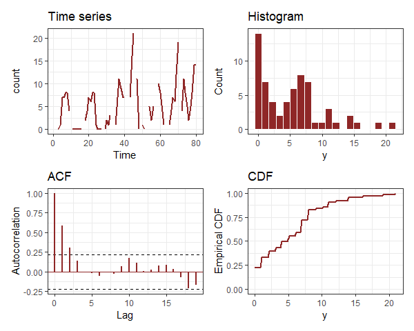

```r
plot_mvgam_series(data = model_data, series = 1, y = "count")
```

## GLMs with temporal random effects

Our first task will be to fit a Generalized Linear Model (GLM) that can adequately capture the features of our `count` observations (integer data, lower bound at zero, missing values) while also attempting to model temporal variation. We are almost ready to fit our first model, which will be a GLM with Poisson observations, a log link function and random (hierarchical) intercepts for `year`. This will allow us to capture our prior belief that, although each year is unique, having been sampled from the same population of effects, all years are connected and thus might contain valuable information about one another. This will be done by capitalizing on the partial pooling properties of hierarchical models. Hierarchical (also known as random) effects offer many advantages when modelling data with grouping structures (i.e. multiple species, locations, years etc…). The ability to incorporate these in time series models is a huge advantage over traditional models such as ARIMA or Exponential Smoothing. But before we fit the model, we will need to convert `year` to a factor so that we can use a random effect basis in `mvgam`. See `?smooth.terms` and `?smooth.construct.re.smooth.spec` for details about the `re` basis construction that is used by both `mvgam` and `mgcv`

```r
model_data %>%
  # Create a 'year_fac' factor version of 'year'
  dplyr::mutate(year_fac = factor(year)) -> model_data
```

Preview the dataset to ensure year is now a factor with a unique factor level for each year in the data

```r
dplyr::glimpse(model_data)
```

```
#> Rows: 80
#> Columns: 7
#> $ series    <fct> PP, PP, PP, PP, PP, PP, PP, PP, PP, PP, PP, PP, PP, PP, PP, …
#> $ year      <int> 1, 1, 1, 1, 1, 1, 1, 1, 1, 1, 1, 1, 2, 2, 2, 2, 2, 2, 2, 2, …
#> $ time      <int> 1, 2, 3, 4, 5, 6, 7, 8, 9, 10, 11, 12, 13, 14, 15, 16, 17, 1…
#> $ count     <int> 0, NA, 0, 1, 7, 7, 8, 8, 4, NA, 0, 0, 0, 0, 0, 0, NA, 2, 4, …
#> $ mintemp   <dbl> -0.79633807, -1.33471597, -1.24166462, -1.08048145, -0.42447…
#> $ ndvi_ma12 <dbl> -0.172144125, -0.237363477, -0.212120638, -0.160438125, -0.0…
#> $ year_fac  <fct> 1, 1, 1, 1, 1, 1, 1, 1, 1, 1, 1, 1, 2, 2, 2, 2, 2, 2, 2, 2, …
```

```r
levels(model_data$year_fac)
```

```
#> [1] "1" "2" "3" "4" "5" "6" "7"
```

We are now ready for our first `mvgam` model. The syntax will be familiar to users who have previously built models with `mgcv`. But for a refresher, see `?formula.gam` and the examples in `?gam`. Random effects can be specified using the `s` wrapper with the `re` basis. Note that we can also suppress the primary intercept using the usual `R` formula syntax `- 1`. `mvgam` has a number of possible observation families that can be used, see `?mvgam_families` for more information. We will use `Stan` as the fitting engine, which deploys Hamiltonian Monte Carlo (HMC) for full Bayesian inference. By default, 4 HMC chains will be run using a warmup of 500 iterations and collecting 500 posterior samples from each chain. The package will also aim to use the `Cmdstan` backend when possible, so it is recommended that users have an up-to-date installation of `Cmdstan` and the associated `cmdstanr` interface on their machines (note that you can set the backend yourself using the `backend` argument: see `?mvgam` for details). Interested users should consult the [`Stan` user’s guide](https://mc-stan.org/docs/stan-users-guide/index.html) for more information about the software and the enormous variety of models that can be tackled with HMC.

```r
model1 <- mvgam(count ~ s(year_fac, bs = "re") - 1,
  family = poisson(),
  data = model_data
)
```

The model can be described mathematically for each timepoint $t$ as follows:
$$\begin{align*}
\boldsymbol{count}_t & \sim \text{Poisson}(\lambda_t) \\
log(\lambda_t) & = \beta_{year[year_t]} \\
\beta_{year} & \sim \text{Normal}(\mu_{year}, \sigma_{year})
\end{align*}$$

Where the $\beta_{year}$ effects are drawn from a *population* distribution that is parameterized by a common mean $(\mu_{year})$ and variance $(\sigma_{year})$. Priors on most of the model parameters can be interrogated and changed using similar functionality to the options available in `brms`. For example, the default priors on $(\mu_{year})$ and $(\sigma_{year})$ can be viewed using the following code:

```r
get_mvgam_priors(count ~ s(year_fac, bs = "re") - 1,
  family = poisson(),
  data = model_data
)
```

```
#>                      param_name param_length           param_info
#> 1             vector[1] mu_raw;            1 s(year_fac) pop mean
#> 2 vector<lower=0>[1] sigma_raw;            1   s(year_fac) pop sd
#>                                  prior                 example_change
#> 1               mu_raw ~ std_normal();  mu_raw ~ normal(-0.01, 0.72);
#> 2 sigma_raw ~ inv_gamma(1.418, 0.452); sigma_raw ~ exponential(0.89);
#>   new_lowerbound new_upperbound
#> 1             NA             NA
#> 2             NA             NA
```

See examples in `?get_mvgam_priors` to find out different ways that priors can be altered. Once the model has finished, the first step is to inspect the `summary` to ensure no major diagnostic warnings have been produced and to quickly summarise posterior distributions for key parameters

```r
summary(model1)
```

```
#> GAM formula:
#> count ~ s(year_fac, bs = "re") - 1
#> <environment: 0x000001c4d8b5c610>
#>
#> Family:
#> poisson
#>
#> Link function:
#> log
#>
#> Trend model:
#> None
#>
#> N series:
#> 1
#>
#> N timepoints:
#> 80
#>
#> Status:
#> Fitted using Stan
#> 4 chains, each with iter = 1000; warmup = 500; thin = 1
#> Total post-warmup draws = 2000
#>
#>
#> GAM coefficient (beta) estimates:
#>                2.5%  50% 97.5% Rhat n_eff
#> s(year_fac).1 0.930 1.30   1.6    1  2498
#> s(year_fac).2 0.880 1.20   1.5    1  2963
#> s(year_fac).3 0.061 0.61   1.0    1  1951
#> s(year_fac).4 2.000 2.30   2.5    1  2545
#> s(year_fac).5 1.100 1.50   1.8    1  2490
#> s(year_fac).6 1.600 1.80   2.1    1  2158
#> s(year_fac).7 1.800 2.10   2.3    1  2632
#>
#> GAM group-level estimates:
#>                   2.5%  50% 97.5% Rhat n_eff
#> mean(s(year_fac)) 0.81 1.50   1.9 1.03   314
#> sd(s(year_fac))   0.36 0.59   1.1 1.02   323
#>
#> Approximate significance of GAM smooths:
#>              edf Ref.df Chi.sq p-value
#> s(year_fac) 6.06      7    235  <2e-16 ***
#> ---
#> Signif. codes:  0 '***' 0.001 '**' 0.01 '*' 0.05 '.' 0.1 ' ' 1
#>
#> Stan MCMC diagnostics:
#> ✔ No issues with effective samples per iteration
#> ✔ Rhat looks good for all parameters
#> ✔ No issues with divergences
#> ✔ No issues with maximum tree depth
#>
#> Samples were drawn using sampling(hmc). For each parameter, n_eff is a
#>   crude measure of effective sample size, and Rhat is the potential scale
#>   reduction factor on split MCMC chains (at convergence, Rhat = 1)
#>
#> Use how_to_cite() to get started describing this model
```

The diagnostic messages at the bottom of the summary show that the HMC sampler did not encounter any problems or difficult posterior spaces. This is a good sign. Posterior distributions for model parameters can be extracted in any way that an object of class `brmsfit` can (see `?mvgam::mvgam_draws` for details). For example, we can extract the coefficients related to the GAM linear predictor (i.e. the $\beta$’s) into a `data.frame` using:

```r
beta_post <- as.data.frame(model1, variable = "betas")
dplyr::glimpse(beta_post)
```

```
#> Rows: 2,000
#> Columns: 7
#> $ `s(year_fac).1` <dbl> 1.27111, 1.02695, 1.40669, 1.16491, 1.07241, 1.40716, …
#> $ `s(year_fac).2` <dbl> 1.213850, 1.298870, 1.254410, 1.203470, 1.068860, 1.05…
#> $ `s(year_fac).3` <dbl> 1.031770, 0.589132, 0.964144, 0.789647, 0.489499, 0.73…
#> $ `s(year_fac).4` <dbl> 2.47327, 2.04142, 2.39684, 2.05263, 2.16672, 2.16459, …
#> $ `s(year_fac).5` <dbl> 1.72034, 1.37969, 1.66357, 1.09216, 1.51792, 1.21841, …
#> $ `s(year_fac).6` <dbl> 1.69803, 1.77055, 1.94107, 1.87749, 1.75392, 1.87220, …
#> $ `s(year_fac).7` <dbl> 2.07783, 2.11586, 2.03418, 2.09586, 2.07859, 1.86252, …
```

With any model fitted in `mvgam`, the underlying `Stan` code can be viewed using the `code` function:

```r
code(model1)
```

```
#> // Stan model code generated by package mvgam
#> data {
#>   int<lower=0> total_obs; // total number of observations
#>   int<lower=0> n; // number of timepoints per series
#>   int<lower=0> n_series; // number of series
#>   int<lower=0> num_basis; // total number of basis coefficients
#>   matrix[total_obs, num_basis] X; // mgcv GAM design matrix
#>   array[n, n_series] int<lower=0> ytimes; // time-ordered matrix (which col in X belongs to each [time, series] observation?)
#>   int<lower=0> n_nonmissing; // number of nonmissing observations
#>   array[n_nonmissing] int<lower=0> flat_ys; // flattened nonmissing observations
#>   matrix[n_nonmissing, num_basis] flat_xs; // X values for nonmissing observations
#>   array[n_nonmissing] int<lower=0> obs_ind; // indices of nonmissing observations
#> }
#> parameters {
#>   // raw basis coefficients
#>   vector[num_basis] b_raw;
#>
#>   // random effect variances
#>   vector<lower=0>[1] sigma_raw;
#>
#>   // random effect means
#>   vector[1] mu_raw;
#> }
#> transformed parameters {
#>   // basis coefficients
#>   vector[num_basis] b;
#>   b[1 : 7] = mu_raw[1] + b_raw[1 : 7] * sigma_raw[1];
#> }
#> model {
#>   // prior for random effect population variances
#>   sigma_raw ~ inv_gamma(1.418, 0.452);
#>
#>   // prior for random effect population means
#>   mu_raw ~ std_normal();
#>
#>   // prior (non-centred) for s(year_fac)...
#>   b_raw[1 : 7] ~ std_normal();
#>   {
#>     // likelihood functions
#>     flat_ys ~ poisson_log_glm(flat_xs, 0.0, b);
#>   }
#> }
#> generated quantities {
#>   vector[total_obs] eta;
#>   matrix[n, n_series] mus;
#>   array[n, n_series] int ypred;
#>
#>   // posterior predictions
#>   eta = X * b;
#>   for (s in 1 : n_series) {
#>     mus[1 : n, s] = eta[ytimes[1 : n, s]];
#>     ypred[1 : n, s] = poisson_log_rng(mus[1 : n, s]);
#>   }
#> }
```

### Plotting effects and residuals

Now for interrogating the model. We can get some sense of the variation in yearly intercepts from the summary above, but it is easier to understand them using targeted plots. Plot posterior distributions of the temporal random effects using `plot.mvgam` with `type = 're'`. See `?plot.mvgam` for more details about the types of plots that can be produced from fitted `mvgam` objects

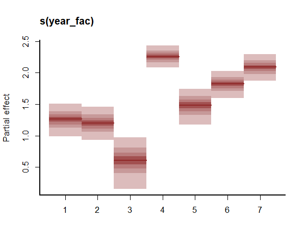

```r
plot(model1, type = "re")
```

### `bayesplot` support

We can also capitalize on most of the useful MCMC plotting functions from the `bayesplot` package to visualize posterior distributions and diagnostics (see `?mvgam::mcmc_plot.mvgam` for details):

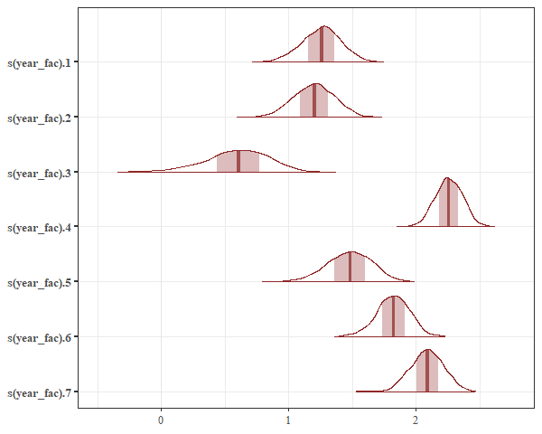

```r
mcmc_plot(
  object = model1,
  variable = "betas",
  type = "areas"
)
```

We can also use the wide range of posterior checking functions available in `bayesplot` (see `?mvgam::ppc_check.mvgam` for details):

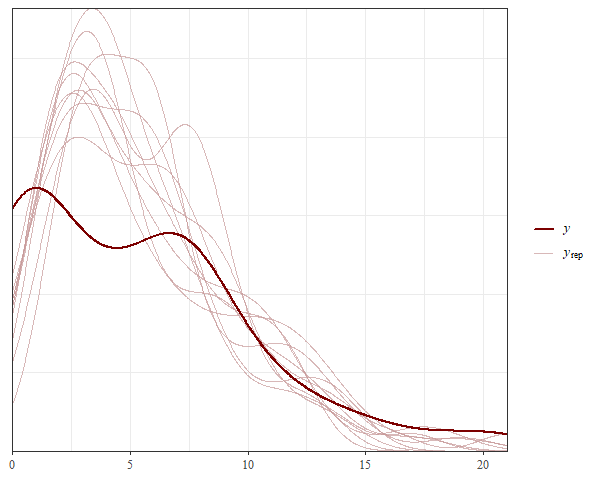

```r
pp_check(object = model1)
```

There is clearly some variation in these yearly intercept estimates. But how do these translate into time-varying predictions? To understand this, we can plot posterior hindcasts from this model for the training period using `plot.mvgam` with `type = 'forecast'`

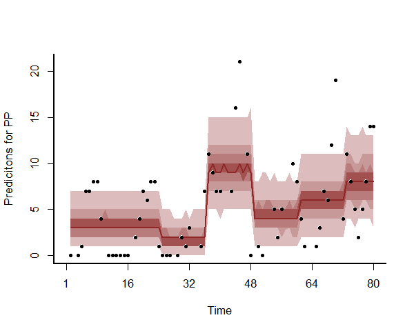

```r
plot(model1, type = "forecast")
```

If you wish to extract these hindcasts for other downstream analyses, the `hindcast` function can be used. This will return a list object of class `mvgam_forecast`. In the `hindcasts` slot, a matrix of posterior retrodictions will be returned for each series in the data (only one series in our example):

```r
hc <- hindcast(model1)
str(hc)
```

```
#> List of 15
#>  $ call              :Class 'formula'  language count ~ s(year_fac, bs = "re") - 1
#>   .. ..- attr(*, ".Environment")=<environment: 0x000001c4d8b5c610>
#>  $ trend_call        : NULL
#>  $ family            : chr "poisson"
#>  $ trend_model       : chr "None"
#>  $ drift             : logi FALSE
#>  $ use_lv            : logi FALSE
#>  $ fit_engine        : chr "stan"
#>  $ type              : chr "response"
#>  $ series_names      : chr "PP"
#>  $ train_observations:List of 1
#>   ..$ PP: int [1:80] 0 NA 0 1 7 7 8 8 4 NA ...
#>  $ train_times       : int [1:80] 1 2 3 4 5 6 7 8 9 10 ...
#>  $ test_observations : NULL
#>  $ test_times        : NULL
#>  $ hindcasts         :List of 1
#>   ..$ PP: num [1:2000, 1:80] 2 2 6 3 3 6 2 2 5 7 ...
#>   .. ..- attr(*, "dimnames")=List of 2
#>   .. .. ..$ : NULL
#>   .. .. ..$ : chr [1:80] "ypred[1,1]" "ypred[2,1]" "ypred[3,1]" "ypred[4,1]" ...
#>  $ forecasts         : NULL
#>  - attr(*, "class")= chr "mvgam_forecast"
```

You can also extract these hindcasts on the linear predictor scale, which in this case is the log scale (our Poisson GLM used a log link function). Sometimes this can be useful for asking more targeted questions about drivers of variation:

```r
hc <- hindcast(model1, type = "link")
range(hc$hindcasts$PP)
```

```
#> [1] -0.343005  2.617440
```

In any regression analysis, a key question is whether the residuals show any patterns that can be indicative of un-modelled sources of variation. For GLMs, we can use a modified residual called the [Dunn-Smyth, or randomized quantile, residual](https://www.jstor.org/stable/1390802). Inspect Dunn-Smyth residuals from the model using `plot.mvgam` with `type = 'residuals'`

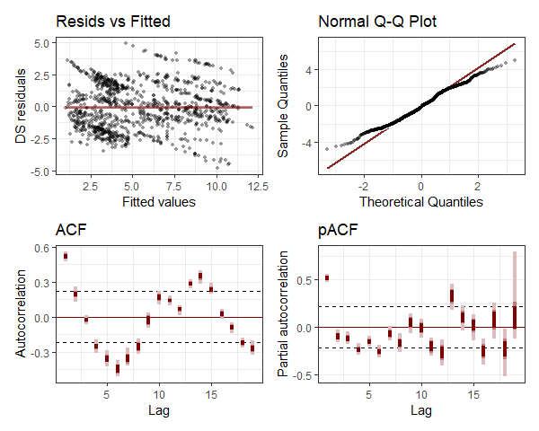

```r
plot(model1, type = "residuals")
```

## Automatic forecasting for new data

These temporal random effects do not have a sense of “time”. Because of this, each yearly random intercept is not restricted in some way to be similar to the previous yearly intercept. This drawback becomes evident when we predict for a new year. To do this, we can repeat the exercise above but this time will split the data into training and testing sets before re-running the model. We can then supply the test set as `newdata`. For splitting, we will make use of the `filter` function from `dplyr`

```r
model_data %>%
  dplyr::filter(time <= 70) -> data_train
model_data %>%
  dplyr::filter(time > 70) -> data_test
```

```r
model1b <- mvgam(count ~ s(year_fac, bs = "re") - 1,
  family = poisson(),
  data = data_train,
  newdata = data_test
)
```

We can view the test data in the forecast plot to see that the predictions do not capture the temporal variation in the test set

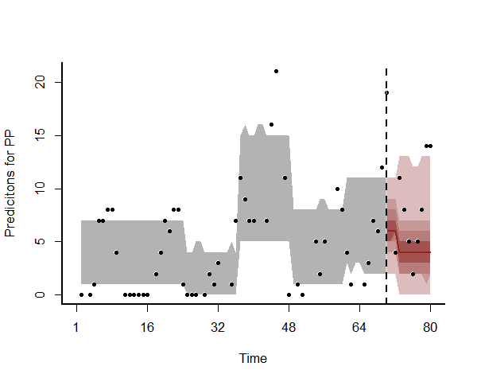

```r
plot(model1b, type = "forecast", newdata = data_test)
```

As with the `hindcast` function, we can use the `forecast` function to automatically extract the posterior distributions for these predictions. This also returns an object of class `mvgam_forecast`, but now it will contain both the hindcasts and forecasts for each series in the data:

```r
fc <- forecast(model1b)
str(fc)
```

```
#> List of 16
#>  $ call              :Class 'formula'  language count ~ s(year_fac, bs = "re") - 1
#>   .. ..- attr(*, ".Environment")=<environment: 0x000001c4d8b5c610>
#>  $ trend_call        : NULL
#>  $ family            : chr "poisson"
#>  $ family_pars       : NULL
#>  $ trend_model       : chr "None"
#>  $ drift             : logi FALSE
#>  $ use_lv            : logi FALSE
#>  $ fit_engine        : chr "stan"
#>  $ type              : chr "response"
#>  $ series_names      : Factor w/ 1 level "PP": 1
#>  $ train_observations:List of 1
#>   ..$ PP: int [1:70] 0 NA 0 1 7 7 8 8 4 NA ...
#>  $ train_times       : int [1:70] 1 2 3 4 5 6 7 8 9 10 ...
#>  $ test_observations :List of 1
#>   ..$ PP: int [1:10] NA 4 11 8 5 2 5 8 14 14
#>  $ test_times        : int [1:10] 71 72 73 74 75 76 77 78 79 80
#>  $ hindcasts         :List of 1
#>   ..$ PP: num [1:2000, 1:70] 1 4 3 1 3 5 4 3 2 3 ...
#>   .. ..- attr(*, "dimnames")=List of 2
#>   .. .. ..$ : NULL
#>   .. .. ..$ : chr [1:70] "ypred[1,1]" "ypred[2,1]" "ypred[3,1]" "ypred[4,1]" ...
#>  $ forecasts         :List of 1
#>   ..$ PP: num [1:2000, 1:10] 8 10 10 7 5 7 5 3 5 1 ...
#>   .. ..- attr(*, "dimnames")=List of 2
#>   .. .. ..$ : NULL
#>   .. .. ..$ : chr [1:10] "ypred[71,1]" "ypred[72,1]" "ypred[73,1]" "ypred[74,1]" ...
#>  - attr(*, "class")= chr "mvgam_forecast"
```

## Adding predictors as “fixed” effects

Any users familiar with GLMs will know that we nearly always wish to include predictor variables that may explain some of the variation in our observations. Predictors are easily incorporated into GLMs / GAMs. Here, we will update the model from above by including a parametric (fixed) effect of `ndvi_ma12` as a linear predictor:

```r
model2 <- mvgam(
  count ~ s(year_fac, bs = "re") +
    ndvi_ma12 - 1,
  family = poisson(),
  data = data_train,
  newdata = data_test
)
```

The model can be described mathematically as follows:
$$\begin{align*}
\boldsymbol{count}_t & \sim \text{Poisson}(\lambda_t) \\
log(\lambda_t) & = \beta_{year[year_t]} + \beta_{ndvi} *
\boldsymbol{ndvi}_t \\
\beta_{year} & \sim \text{Normal}(\mu_{year}, \sigma_{year}) \\
\beta_{ndvi} & \sim \text{Normal}(0, 1) \end{align*}$$

Where the $\beta_{year}$ effects are the same as before but we now have another predictor $(\beta_{ndvi})$ that applies to the `ndvi_ma12` value at each timepoint $t$. Inspect the summary of this model

```r
summary(model2)
```

```
#> GAM formula:
#> count ~ ndvi_ma12 + s(year_fac, bs = "re") - 1
#> <environment: 0x000001c4d8b5c610>
#>
#> Family:
#> poisson
#>
#> Link function:
#> log
#>
#> Trend model:
#> None
#>
#> N series:
#> 1
#>
#> N timepoints:
#> 80
#>
#> Status:
#> Fitted using Stan
#> 4 chains, each with iter = 1000; warmup = 500; thin = 1
#> Total post-warmup draws = 2000
#>
#>
#> GAM coefficient (beta) estimates:
#>                 2.5%   50% 97.5% Rhat n_eff
#> ndvi_ma12     -0.430 0.037  0.48    1  1246
#> s(year_fac).1  0.910 1.300  1.60    1  2000
#> s(year_fac).2  0.850 1.200  1.50    1  2256
#> s(year_fac).3  0.039 0.590  1.00    1  2006
#> s(year_fac).4  2.000 2.300  2.50    1  2025
#> s(year_fac).5  1.100 1.500  1.80    1  2032
#> s(year_fac).6  1.600 1.800  2.10    1  2314
#> s(year_fac).7 -0.260 1.400  2.70    1  1165
#>
#> GAM group-level estimates:
#>                   2.5%  50% 97.5% Rhat n_eff
#> mean(s(year_fac)) 0.67 1.40   1.8 1.01   503
#> sd(s(year_fac))   0.33 0.59   1.2 1.00   674
#>
#> Approximate significance of GAM smooths:
#>              edf Ref.df Chi.sq p-value
#> s(year_fac) 5.15      7    181  <2e-16 ***
#> ---
#> Signif. codes:  0 '***' 0.001 '**' 0.01 '*' 0.05 '.' 0.1 ' ' 1
#>
#> Stan MCMC diagnostics:
#> ✔ No issues with effective samples per iteration
#> ✔ Rhat looks good for all parameters
#> ✔ No issues with divergences
#> ✔ No issues with maximum tree depth
#>
#> Samples were drawn using sampling(hmc). For each parameter, n_eff is a
#>   crude measure of effective sample size, and Rhat is the potential scale
#>   reduction factor on split MCMC chains (at convergence, Rhat = 1)
#>
#> Use how_to_cite() to get started describing this model
```

Rather than printing the summary each time, we can also quickly look at the posterior empirical quantiles for the fixed effect of `ndvi` (and other linear predictor coefficients) using `coef`:

```r
coef(model2)
```

```
#>                      2.5%       50%     97.5% Rhat n_eff
#> ndvi_ma12     -0.43009490 0.0368380 0.4807686    1  1246
#> s(year_fac).1  0.90707552 1.2527900 1.5707007    1  2000
#> s(year_fac).2  0.85259573 1.1959200 1.5062270    1  2256
#> s(year_fac).3  0.03939698 0.5938815 1.0232462    1  2006
#> s(year_fac).4  2.02394125 2.2574300 2.4830372    1  2025
#> s(year_fac).5  1.10133825 1.4647050 1.7940193    1  2032
#> s(year_fac).6  1.58446800 1.8492950 2.1121342    1  2314
#> s(year_fac).7 -0.25900887 1.3565700 2.7387117    1  1165
```

Look at the estimated effect of `ndvi` using using a histogram. This can be done by first extracting the posterior coefficients:

```r
beta_post <- as.data.frame(model2, variable = "betas")
dplyr::glimpse(beta_post)
```

```
#> Rows: 2,000
#> Columns: 8
#> $ ndvi_ma12       <dbl> 0.090007500, 0.057366600, 0.134242000, 0.206417000, -0…
#> $ `s(year_fac).1` <dbl> 1.290350, 1.097560, 1.496160, 0.883781, 1.057800, 1.07…
#> $ `s(year_fac).2` <dbl> 1.033210, 1.323910, 1.088810, 1.440260, 1.289660, 1.14…
#> $ `s(year_fac).3` <dbl> 0.5887790, 0.3832800, 0.3038570, 0.4566980, 0.8948710,…
#> $ `s(year_fac).4` <dbl> 2.21495, 2.20053, 2.36647, 2.46827, 2.31756, 2.18923, …
#> $ `s(year_fac).5` <dbl> 1.44163, 1.28825, 1.67381, 1.58269, 1.61572, 1.38098, …
#> $ `s(year_fac).6` <dbl> 1.98269, 1.89082, 1.81337, 1.88566, 1.99755, 1.62267, …
#> $ `s(year_fac).7` <dbl> 0.2797950, -0.1616520, 2.4094700, 2.4182800, 1.0658400…
```

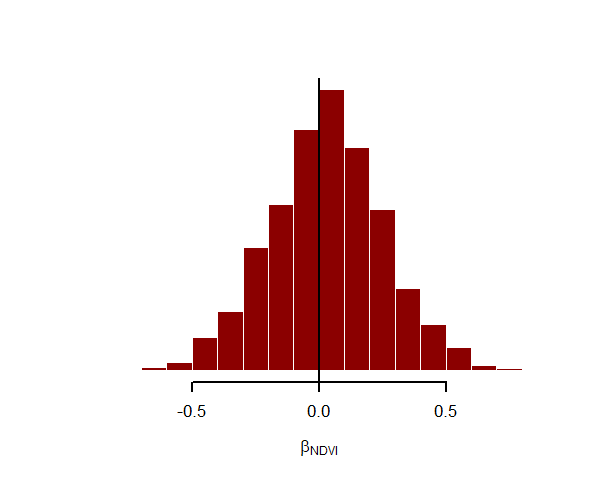

```r
hist(beta_post$ndvi_ma12,
  xlim = c(
    -1 * max(abs(beta_post$ndvi_ma12)),
    max(abs(beta_post$ndvi))
  ),
  col = "darkred",
  border = "white",
  xlab = expression(beta[NDVI]),
  ylab = "",
  yaxt = "n",
  main = "",
  lwd = 2
)
abline(v = 0, lwd = 2.5)
```

### `marginaleffects` support

Given our model used a nonlinear link function (log link in this example), it can still be difficult to fully understand what relationship our model is estimating between a predictor and the response. Fortunately, the `marginaleffects` package makes this relatively straightforward. Objects of class `mvgam` can be used with `marginaleffects` to inspect contrasts, scenario-based predictions, conditional and marginal effects, all on the outcome scale. Like `brms`, `mvgam` has the simple `conditional_effects` function to make quick and informative plots for main effects, which rely on `marginaleffects` support. This will likely be your go-to function for quickly understanding patterns from fitted `mvgam` models

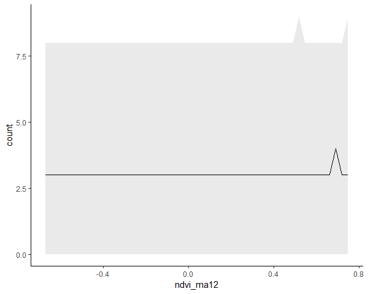

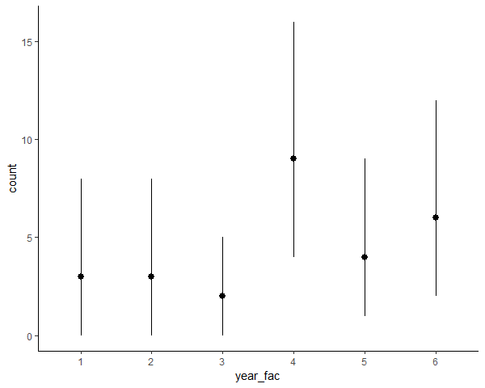

```r
conditional_effects(model2)
```

## Adding predictors as smooths

```r
model3 <- mvgam(
  count ~ s(time, bs = "bs", k = 15) +
    ndvi_ma12,
  family = poisson(),
  data = data_train,
  newdata = data_test
)
```

The model can be described mathematically as follows:
$$\begin{align*}
\boldsymbol{count}_t & \sim \text{Poisson}(\lambda_t) \\
log(\lambda_t) & = f(\boldsymbol{time})_t + \beta_{ndvi} *
\boldsymbol{ndvi}_t \\
f(\boldsymbol{time}) & = \sum_{k=1}^{K}b * \beta_{smooth} \\
\beta_{smooth} & \sim \text{MVNormal}(0, (\Omega * \lambda)^{-1}) \\
\beta_{ndvi} & \sim \text{Normal}(0, 1) \end{align*}$$

```r
summary(model3)
```

```
#> GAM formula:
#> count ~ s(time, bs = "bs", k = 15) + ndvi_ma12
#> <environment: 0x000001c4d8b5c610>
#>
#> Family:
#> poisson
#>
#> Link function:
#> log
#>
#> Trend model:
#> None
#>
#> N series:
#> 1
#>
#> N timepoints:
#> 80
#>
#> Status:
#> Fitted using Stan
#> 4 chains, each with iter = 1000; warmup = 500; thin = 1
#> Total post-warmup draws = 2000
#>
#>
#> GAM coefficient (beta) estimates:
#>               2.5%   50% 97.5% Rhat n_eff
#> (Intercept)   0.80  1.10  1.30 1.00   953
#> ndvi_ma12     0.35  1.90  3.50 1.00  1011
#> s(time).1    -9.80 -5.80 -2.70 1.00   571
#> s(time).2     1.10  3.40  5.80 1.01   480
#> s(time).3   -10.00 -6.30 -2.70 1.00   485
#> s(time).4    -1.80  0.78  3.20 1.01   408
#> s(time).5    -2.90 -0.39  2.30 1.00   388
#> s(time).6    -6.80 -3.90 -1.20 1.00   466
#> s(time).7    -1.90  0.61  2.90 1.01   357
#> s(time).8    -2.50 -0.13  2.30 1.00   379
#> s(time).9    -0.57  2.10  4.80 1.01   369
#> s(time).10   -5.70 -3.30 -0.92 1.00   428
#> s(time).11   -2.50  0.53  3.90 1.01   504
#> s(time).12   -6.80 -5.00 -3.20 1.00   666
#> s(time).13    1.60  5.00  8.40 1.01   364
#> s(time).14  -11.00 -3.10  4.70 1.01   362
#>
#> Approximate significance of GAM smooths:
#>          edf Ref.df Chi.sq p-value
#> s(time) 12.1     14    102  <2e-16 ***
#> ---
#> Signif. codes:  0 '***' 0.001 '**' 0.01 '*' 0.05 '.' 0.1 ' ' 1
#>
#> Stan MCMC diagnostics:
#> ✔ No issues with effective samples per iteration
#> ✔ Rhat looks good for all parameters
#> ✔ No issues with divergences
#> ✔ No issues with maximum tree depth
#>
#> Samples were drawn using sampling(hmc). For each parameter, n_eff is a
#>   crude measure of effective sample size, and Rhat is the potential scale
#>   reduction factor on split MCMC chains (at convergence, Rhat = 1)
#>
#> Use how_to_cite() to get started describing this model
```

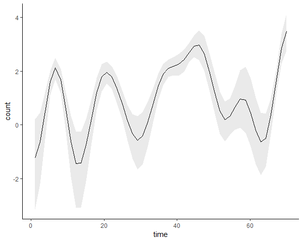

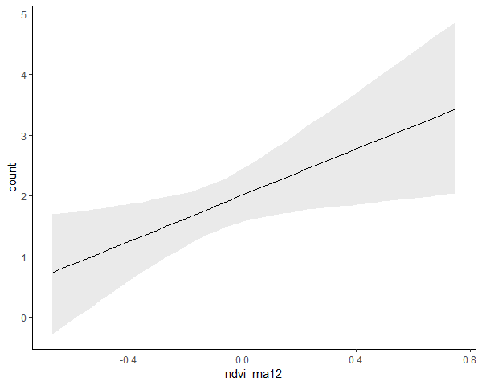

```r
conditional_effects(model3, type = "link")
```

Inspect the underlying `Stan` code to gain some idea of how the spline is being penalized:

```r
code(model3)
```

```
#> // Stan model code generated by package mvgam
#> data {
#>   int<lower=0> total_obs; // total number of observations
#>   int<lower=0> n; // number of timepoints per series
#>   int<lower=0> n_sp; // number of smoothing parameters
#>   int<lower=0> n_series; // number of series
#>   int<lower=0> num_basis; // total number of basis coefficients
#>   vector[num_basis] zero; // prior locations for basis coefficients
#>   matrix[total_obs, num_basis] X; // mgcv GAM design matrix
#>   array[n, n_series] int<lower=0> ytimes; // time-ordered matrix (which col in X belongs to each [time, series] observation?)
#>   matrix[14, 28] S1; // mgcv smooth penalty matrix S1
#>   int<lower=0> n_nonmissing; // number of nonmissing observations
#>   array[n_nonmissing] int<lower=0> flat_ys; // flattened nonmissing observations
#>   matrix[n_nonmissing, num_basis] flat_xs; // X values for nonmissing observations
#>   array[n_nonmissing] int<lower=0> obs_ind; // indices of nonmissing observations
#> }
#> parameters {
#>   // raw basis coefficients
#>   vector[num_basis] b_raw;
#>
#>   // smoothing parameters
#>   vector<lower=0>[n_sp] lambda;
#> }
#> transformed parameters {
#>   // basis coefficients
#>   vector[num_basis] b;
#>   b[1 : num_basis] = b_raw[1 : num_basis];
#> }
#> model {
#>   // prior for (Intercept)...
#>   b_raw[1] ~ student_t(3, 1.4, 2.5);
#>
#>   // prior for ndvi_ma12...
#>   b_raw[2] ~ student_t(3, 0, 2);
#>
#>   // prior for s(time)...
#>   b_raw[3 : 16] ~ multi_normal_prec(zero[3 : 16],
#>                                     S1[1 : 14, 1 : 14] * lambda[1]
#>                                     + S1[1 : 14, 15 : 28] * lambda[2]);
#>
#>   // priors for smoothing parameters
#>   lambda ~ normal(5, 30);
#>   {
#>     // likelihood functions
#>     flat_ys ~ poisson_log_glm(flat_xs, 0.0, b);
#>   }
#> }
#> generated quantities {
#>   vector[total_obs] eta;
#>   matrix[n, n_series] mus;
#>   vector[n_sp] rho;
#>   array[n, n_series] int ypred;
#>   rho = log(lambda);
#>
#>   // posterior predictions
#>   eta = X * b;
#>   for (s in 1 : n_series) {
#>     mus[1 : n, s] = eta[ytimes[1 : n, s]];
#>     ypred[1 : n, s] = poisson_log_rng(mus[1 : n, s]);
#>   }
#> }
```

The line below `// prior for s(time)...` shows how the spline basis coefficients are drawn from a zero-centred multivariate normal distribution. The precision matrix $S$ is penalized by two different smoothing parameters (the $\lambda$’s) to enforce smoothness and reduce overfitting

## Latent dynamics in `mvgam`

Forecasts from the above model are not ideal:

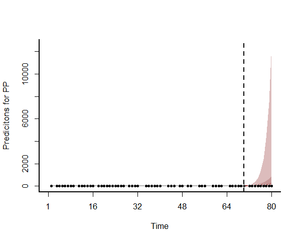

```r
plot(model3, type = "forecast", newdata = data_test)
```

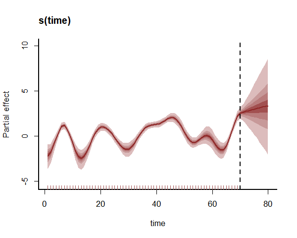

```r
plot_mvgam_smooth(model3,
  smooth = "s(time)",
  # feed newdata to the plot function to generate
  # predictions of the temporal smooth to the end of the
  # testing period
  newdata = data.frame(
    time = 1:max(data_test$time),
    ndvi_ma12 = 0
  )
)
abline(v = max(data_train$time), lty = "dashed", lwd = 2)
```

This model is not doing well. Clearly we need to somehow account for the strong temporal autocorrelation when modelling these data without using a smooth function of `time`. Now onto another prominent feature of `mvgam`: the ability to include (possibly latent) autocorrelated residuals in regression models. To do so, we use the `trend_model` argument (see `?mvgam_trends` for details of different dynamic trend models that are supported). This model will use a separate sub-model for latent residuals that evolve as an AR1 process (i.e. the error in the current time point is a function of the error in the previous time point, plus some stochastic noise). We also include a smooth function of `ndvi_ma12` in this model, rather than the parametric term that was used above, to showcase that `mvgam` can include combinations of smooths and dynamic components:

```r
model4 <- mvgam(count ~ s(ndvi_ma12, k = 6),
  family = poisson(),
  data = data_train,
  newdata = data_test,
  trend_model = AR()
)
```

The model can be described mathematically as follows:
$$\begin{align*}
\boldsymbol{count}_t & \sim \text{Poisson}(\lambda_t) \\
log(\lambda_t) & = f(\boldsymbol{ndvi})_t + z_t \\
z_t & \sim \text{Normal}(ar1 * z_{t-1}, \sigma_{error}) \\
ar1 & \sim \text{Normal}(0, 1)[-1, 1] \\
\sigma_{error} & \sim \text{Exponential}(2) \\
f(\boldsymbol{ndvi}) & = \sum_{k=1}^{K}b * \beta_{smooth} \\
\beta_{smooth} & \sim \text{MVNormal}(0, (\Omega * \lambda)^{-1})
\end{align*}$$

Here the term $z_t$ captures autocorrelated latent residuals, which are modelled using an AR1 process. You can also notice that this model is estimating autocorrelated errors for the full time period, even though some of these time points have missing observations. This is useful for getting more realistic estimates of the residual autocorrelation parameters. Summarise the model to see how it now returns posterior summaries for the latent AR1 process:

```r
summary(model4)
```

```
#> GAM formula:
#> count ~ s(ndvi_ma12, k = 6)
#> <environment: 0x000001c4d8b5c610>
#>
#> Family:
#> poisson
#>
#> Link function:
#> log
#>
#> Trend model:
#> AR()
#>
#>
#> N series:
#> 1
#>
#> N timepoints:
#> 80
#>
#> Status:
#> Fitted using Stan
#> 4 chains, each with iter = 1000; warmup = 500; thin = 1
#> Total post-warmup draws = 2000
#>
#>
#> GAM coefficient (beta) estimates:
#>                 2.5%      50% 97.5% Rhat n_eff
#> (Intercept)    -1.20  0.66000 1.600    1   191
#> s(ndvi_ma12).1 -0.15  0.00390 0.170    1  1326
#> s(ndvi_ma12).2 -0.19 -0.00540 0.180    1  1230
#> s(ndvi_ma12).3 -0.06 -0.00066 0.068    1  1232
#> s(ndvi_ma12).4 -0.45  0.01800 0.490    1  1021
#> s(ndvi_ma12).5 -0.32  0.07700 0.490    1   809
#>
#> Approximate significance of GAM smooths:
#>                edf Ref.df Chi.sq p-value
#> s(ndvi_ma12) 0.653      5   0.69       1
#>
#> Latent trend parameter AR estimates:
#>          2.5%  50% 97.5% Rhat n_eff
#> ar1[1]   0.62 0.83  0.98 1.01   411
#> sigma[1] 0.58 0.81  1.10 1.01   362
#>
#> Stan MCMC diagnostics:
#> ✔ No issues with effective samples per iteration
#> ✔ Rhat looks good for all parameters
#> ✔ No issues with divergences
#> ✔ No issues with maximum tree depth
#>
#> Samples were drawn using sampling(hmc). For each parameter, n_eff is a
#>   crude measure of effective sample size, and Rhat is the potential scale
#>   reduction factor on split MCMC chains (at convergence, Rhat = 1)
#>
#> Use how_to_cite() to get started describing this model
```

View posterior hindcasts / forecasts and compare against the out of sample test data

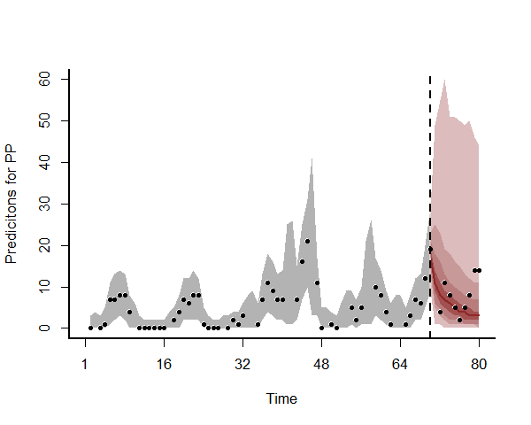

```r
plot(model4, type = "forecast", newdata = data_test)
```

The trend is evolving as an AR1 process, which we can also view:

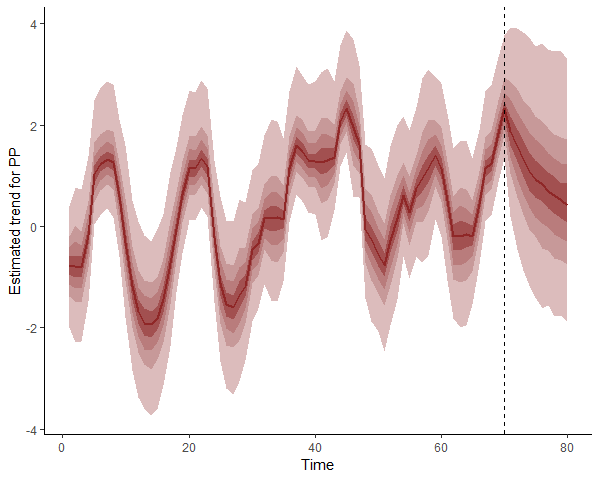

```r
plot(model4, type = "trend", newdata = data_test)
```

In-sample model performance can be interrogated using leave-one-out cross-validation utilities from the `loo` package (a higher value is preferred for this metric):

```r
loo_compare(model3, model4)
```

```
#>        elpd_diff se_diff
#> model4  0.0       0.0
#> model3 -2.4       5.5
```

The higher estimated log predictive density (ELPD) value for the dynamic model suggests it provides a better fit to the in-sample data.

Though it should be obvious that this model provides better forecasts, we can quantify forecast performance for models 3 and 4 using the `forecast` and `score` functions. Here we will compare models based on their Discrete Ranked Probability Scores (a lower value is preferred for this metric)

```r
fc_mod3 <- forecast(model3)
fc_mod4 <- forecast(model4)
score_mod3 <- score(fc_mod3, score = "drps")
score_mod4 <- score(fc_mod4, score = "drps")
sum(score_mod4$PP$score, na.rm = TRUE) - sum(score_mod3$PP$score, na.rm = TRUE)
```

```
#> [1] -686.5155
```

A strongly negative value here suggests the score for the dynamic model (model 4) is much smaller than the score for the model with a smooth function of time (model 3)

## Further reading

The following papers and resources offer useful material about Dynamic GAMs and how they can be applied in practice:

Clark, Nicholas J. and Wells, K. [Dynamic Generalized Additive Models (DGAMs) for forecasting discrete ecological time series](https://doi.org/10.1111/2041-210X.13974). *Methods in Ecology and Evolution*. (2023): 14, 771-784.

Clark, Nicholas J., et al. [Beyond single-species models: leveraging multispecies forecasts to navigate the dynamics of ecological predictability](https://peerj.com/articles/18929/). *PeerJ*. (2025): 13:e18929

de Sousa, Heitor C., et al. [Severe fire regimes decrease resilience of ectothermic populations](https://doi.org/10.1111/1365-2656.14188). *Journal of Animal Ecology* (2024): 93(11), 1656-1669.

Hannaford, Naomi E., et al. [A sparse Bayesian hierarchical vector autoregressive model for microbial dynamics in a wastewater treatment plant.](https://doi.org/10.1016/j.csda.2022.107659) *Computational Statistics & Data Analysis* (2023): 179, 107659.

Karunarathna, K.A.N.K., et al. [Modelling nonlinear responses of a desert rodent species to environmental change with hierarchical dynamic generalized additive models](https://doi.org/10.1016/j.ecolmodel.2024.110648). *Ecological Modelling* (2024): 490, 110648.

Zhu, L., et al. [Responses of a widespread pest insect to extreme high temperatures are stage-dependent and divergent among seasonal cohorts](https://doi.org/10.1111/1365-2435.14711). *Functional Ecology* (2025): 39, 165–180. https://doi.org/10.1111/1365-2435.14711

## Interested in contributing?

I’m actively seeking PhD students and other researchers to work in the areas of ecological forecasting, multivariate model evaluation and development of `mvgam`. Please see [this small list of opportunities on my website](https://ecogambler.netlify.app/opportunities/) and do reach out if you are interested (n.clark’at’uq.edu.au)